# Data Sourcing

```python
# Importing packages for analysis
import numpy as np
import pandas as pd
from datetime import datetime as dt
import matplotlib.pyplot as plt
import seaborn as sns
```

```python
#Importing the dataset for analysis
loan = pd.read_csv('loan.csv')
loan.head(5)
```

|  | id | member_id | loan_amnt | funded_amnt | funded_amnt_inv | term | int_rate | installment | grade | sub_grade | ... | num_tl_90g_dpd_24m | num_tl_op_past_12m | pct_tl_nvr_dlq | percent_bc_gt_75 | pub_rec_bankruptcies | tax_liens | tot_hi_cred_lim | total_bal_ex_mort | total_bc_limit | total_il_high_credit_limit |
| --- | --- | --- | --- | --- | --- | --- | --- | --- | --- | --- | --- | --- | --- | --- | --- | --- | --- | --- | --- | --- | --- |
| 0 | 1077501 | 1296599 | 5000 | 5000 | 4975.0 | 36 months | 10.65% | 162.87 | B | B2 | ... | NaN | NaN | NaN | NaN | 0.0 | 0.0 | NaN | NaN | NaN | NaN |
| 1 | 1077430 | 1314167 | 2500 | 2500 | 2500.0 | 60 months | 15.27% | 59.83 | C | C4 | ... | NaN | NaN | NaN | NaN | 0.0 | 0.0 | NaN | NaN | NaN | NaN |
| 2 | 1077175 | 1313524 | 2400 | 2400 | 2400.0 | 36 months | 15.96% | 84.33 | C | C5 | ... | NaN | NaN | NaN | NaN | 0.0 | 0.0 | NaN | NaN | NaN | NaN |
| 3 | 1076863 | 1277178 | 10000 | 10000 | 10000.0 | 36 months | 13.49% | 339.31 | C | C1 | ... | NaN | NaN | NaN | NaN | 0.0 | 0.0 | NaN | NaN | NaN | NaN |
| 4 | 1075358 | 1311748 | 3000 | 3000 | 3000.0 | 60 months | 12.69% | 67.79 | B | B5 | ... | NaN | NaN | NaN | NaN | 0.0 | 0.0 | NaN | NaN | NaN | NaN |

5 rows × 111 columns

# Structure of data: Size, Shape, Data Types..

```python
# Size of the dataframe
loan.shape
```

```
(39717, 111)
```

```python
# Datatypes of all the columns
pd.set_option('display.max_columns', 200)
pd.set_option('display.max_rows', 200)
loan.dtypes
```

```
id                                  int64
member_id                           int64
loan_amnt                           int64
funded_amnt                         int64
funded_amnt_inv                   float64
term                               object
int_rate                           object
installment                       float64
grade                              object
sub_grade                          object
emp_title                          object
emp_length                         object
home_ownership                     object
annual_inc                        float64
verification_status                object
issue_d                            object
loan_status                        object
pymnt_plan                         object
url                                object
desc                               object
purpose                            object
title                              object
zip_code                           object
addr_state                         object
dti                               float64
delinq_2yrs                         int64
earliest_cr_line                   object
inq_last_6mths                      int64
mths_since_last_delinq            float64
mths_since_last_record            float64
open_acc                            int64
pub_rec                             int64
revol_bal                           int64
revol_util                         object
total_acc                           int64
initial_list_status                object
out_prncp                         float64
out_prncp_inv                     float64
total_pymnt                       float64
total_pymnt_inv                   float64
```

[output cut: 57 more lines]

```
num_rev_tl_bal_gt_0               float64
num_sats                          float64
num_tl_120dpd_2m                  float64
num_tl_30dpd                      float64
num_tl_90g_dpd_24m                float64
num_tl_op_past_12m                float64
pct_tl_nvr_dlq                    float64
percent_bc_gt_75                  float64
pub_rec_bankruptcies              float64
tax_liens                         float64
tot_hi_cred_lim                   float64
total_bal_ex_mort                 float64
total_bc_limit                    float64
total_il_high_credit_limit        float64
dtype: object
```

```python
#Summary of data
loan.describe(include = 'all')
```

|  | id | member_id | loan_amnt | funded_amnt | funded_amnt_inv | term | int_rate | installment | grade | sub_grade | emp_title | emp_length | home_ownership | annual_inc | verification_status | issue_d | loan_status | pymnt_plan | url | desc | purpose | title | zip_code | addr_state | dti | delinq_2yrs | earliest_cr_line | inq_last_6mths | mths_since_last_delinq | … |
| --- | --- | --- | --- | --- | --- | --- | --- | --- | --- | --- | --- | --- | --- | --- | --- | --- | --- | --- | --- | --- | --- | --- | --- | --- | --- | --- | --- | --- | --- | --- |
| count | 3.971700e+04 | 3.971700e+04 | 39717.000000 | 39717.000000 | 39717.000000 | 39717 | 39717 | 39717.000000 | 39717 | 39717 | 37258 | 38642 | 39717 | 3.971700e+04 | 39717 | 39717 | 39717 | 39717 | 39717 | 26777 | 39717 | 39706 | 39717 | 39717 | 39717.000000 | 39717.000000 | 39717 | 39717.000000 | 14035.000000 | … |
| unique | NaN | NaN | NaN | NaN | NaN | 2 | 371 | NaN | 7 | 35 | 28820 | 11 | 5 | NaN | 3 | 55 | 3 | 1 | 39717 | 26527 | 14 | 19615 | 823 | 50 | NaN | NaN | 526 | NaN | NaN | … |
| top | NaN | NaN | NaN | NaN | NaN | 36 months | 10.99% | NaN | B | B3 | US Army | 10+ years | RENT | NaN | Not Verified | Dec-11 | Fully Paid | n | https://lendingclub.com/browse/loanDetail.acti... |  | debt_consolidation | Debt Consolidation | 100xx | CA | NaN | NaN | Nov-98 | NaN | NaN | … |
| freq | NaN | NaN | NaN | NaN | NaN | 29096 | 956 | NaN | 12020 | 2917 | 134 | 8879 | 18899 | NaN | 16921 | 2260 | 32950 | 39717 | 1 | 210 | 18641 | 2184 | 597 | 7099 | NaN | NaN | 370 | NaN | NaN | … |
| mean | 6.831319e+05 | 8.504636e+05 | 11219.443815 | 10947.713196 | 10397.448868 | NaN | NaN | 324.561922 | NaN | NaN | NaN | NaN | NaN | 6.896893e+04 | NaN | NaN | NaN | NaN | NaN | NaN | NaN | NaN | NaN | NaN | 13.315130 | 0.146512 | NaN | 0.869200 | 35.900962 | … |
| std | 2.106941e+05 | 2.656783e+05 | 7456.670694 | 7187.238670 | 7128.450439 | NaN | NaN | 208.874874 | NaN | NaN | NaN | NaN | NaN | 6.379377e+04 | NaN | NaN | NaN | NaN | NaN | NaN | NaN | NaN | NaN | NaN | 6.678594 | 0.491812 | NaN | 1.070219 | 22.020060 | … |
| min | 5.473400e+04 | 7.069900e+04 | 500.000000 | 500.000000 | 0.000000 | NaN | NaN | 15.690000 | NaN | NaN | NaN | NaN | NaN | 4.000000e+03 | NaN | NaN | NaN | NaN | NaN | NaN | NaN | NaN | NaN | NaN | 0.000000 | 0.000000 | NaN | 0.000000 | 0.000000 | … |
| 25% | 5.162210e+05 | 6.667800e+05 | 5500.000000 | 5400.000000 | 5000.000000 | NaN | NaN | 167.020000 | NaN | NaN | NaN | NaN | NaN | 4.040400e+04 | NaN | NaN | NaN | NaN | NaN | NaN | NaN | NaN | NaN | NaN | 8.170000 | 0.000000 | NaN | 0.000000 | 18.000000 | … |
| 50% | 6.656650e+05 | 8.508120e+05 | 10000.000000 | 9600.000000 | 8975.000000 | NaN | NaN | 280.220000 | NaN | NaN | NaN | NaN | NaN | 5.900000e+04 | NaN | NaN | NaN | NaN | NaN | NaN | NaN | NaN | NaN | NaN | 13.400000 | 0.000000 | NaN | 1.000000 | 34.000000 | … |
| 75% | 8.377550e+05 | 1.047339e+06 | 15000.000000 | 15000.000000 | 14400.000000 | NaN | NaN | 430.780000 | NaN | NaN | NaN | NaN | NaN | 8.230000e+04 | NaN | NaN | NaN | NaN | NaN | NaN | NaN | NaN | NaN | NaN | 18.600000 | 0.000000 | NaN | 1.000000 | 52.000000 | … |
| max | 1.077501e+06 | 1.314167e+06 | 35000.000000 | 35000.000000 | 35000.000000 | NaN | NaN | 1305.190000 | NaN | NaN | NaN | NaN | NaN | 6.000000e+06 | NaN | NaN | NaN | NaN | NaN | NaN | NaN | NaN | NaN | NaN | 29.990000 | 11.000000 | NaN | 8.000000 | 120.000000 | … |

# Data Cleansing

```python
# Lets check for duplicate records in our data.
loan.drop_duplicates()
loan.shape
# seeems like there are none.
```

```
(39717, 111)
```

```python
# As we are interested to figure out if a borrower is defaulter or not, the loan_status of interest is FULLY PAID and CHARGED OFF
# Lets remove all loans with statuses = "CURRENT" as its uncertain as to know if they will repay the loan or not
loan = loan.loc[loan['loan_status']!='Current']
loan.shape
```

```
(38577, 111)
```

```python
# Percentage of null values in  columns
total = pd.DataFrame(loan.isnull().sum().sort_values(ascending=False), columns=['Total'])
percentage = pd.DataFrame(round(100*(loan.isnull().sum()/loan.shape[0]),2).sort_values(ascending=False),columns=['Percentage'])
pd.concat([total, percentage], axis = 1)
```

|  | Total | Percentage |
| --- | --- | --- |
| total_il_high_credit_limit | 38577 | 100.00 |
| il_util | 38577 | 100.00 |
| bc_util | 38577 | 100.00 |
| bc_open_to_buy | 38577 | 100.00 |
| avg_cur_bal | 38577 | 100.00 |
| acc_open_past_24mths | 38577 | 100.00 |
| inq_last_12m | 38577 | 100.00 |
| total_cu_tl | 38577 | 100.00 |
| inq_fi | 38577 | 100.00 |
| total_rev_hi_lim | 38577 | 100.00 |
| all_util | 38577 | 100.00 |
| max_bal_bc | 38577 | 100.00 |
| open_rv_24m | 38577 | 100.00 |
| open_rv_12m | 38577 | 100.00 |
| total_bal_il | 38577 | 100.00 |
| mo_sin_old_rev_tl_op | 38577 | 100.00 |
| mths_since_rcnt_il | 38577 | 100.00 |
| open_il_24m | 38577 | 100.00 |
| open_il_12m | 38577 | 100.00 |
| open_il_6m | 38577 | 100.00 |
| open_acc_6m | 38577 | 100.00 |
| tot_cur_bal | 38577 | 100.00 |
| tot_coll_amt | 38577 | 100.00 |
| total_bc_limit | 38577 | 100.00 |
| dti_joint | 38577 | 100.00 |
| annual_inc_joint | 38577 | 100.00 |
| mths_since_last_major_derog | 38577 | 100.00 |
| next_pymnt_d | 38577 | 100.00 |
| mo_sin_old_il_acct | 38577 | 100.00 |
| verification_status_joint | 38577 | 100.00 |

[output cut: 81 more lines]

```python
# Dropping all columns with only null values
loan=loan.dropna(axis=1,how='all')
loan.shape
```

```
(38577, 56)
```

#### Checkout some of the categorical variables

```python
loan.emp_length.unique()
```

```
array(['10+ years', '< 1 year', '3 years', '8 years', '9 years',
       '4 years', '5 years', '1 year', '6 years', '2 years', '7 years',
       nan], dtype=object)
```

```python
loan.collections_12_mths_ex_med.unique()
```

```
array([ 0., nan])
```

```python
loan.chargeoff_within_12_mths.unique()
```

```
array([ 0., nan])
```

```python
loan.pub_rec_bankruptcies.unique()
```

```
array([ 0.,  1.,  2., nan])
```

```python
loan.tax_liens.unique()
```

```
array([ 0., nan])
```

##### The columns collections_12_mths_ex_med, chargeoff_within_12_mths and tax_liens has either value of 0 or nan. The range of values that these categorical columns can take is not of any significant impact to the analysis.

#### We can decide to drop these columns for analysis.

```python
# Removing columns that is not of interest for our analysis along with columns that has many null values
drop_columns = ['desc','title','url','mths_since_last_record','mths_since_last_delinq','collections_12_mths_ex_med',
                'last_pymnt_d','revol_util','collections_12_mths_ex_med','chargeoff_within_12_mths','tax_liens',
               'pymnt_plan','zip_code','initial_list_status','policy_code','application_type','acc_now_delinq','delinq_amnt',]
loan = loan.drop(drop_columns, axis=1)
loan.shape
```

```
(38577, 39)
```

```python
# Percentage of null values in columns
total = pd.DataFrame(loan.isnull().sum().sort_values(ascending=False), columns=['Total'])
percentage = pd.DataFrame(round(100*(loan.isnull().sum()/loan.shape[0]),2).sort_values(ascending=False),columns=['Percentage'])
pd.concat([total, percentage], axis = 1)
```

|  | Total | Percentage |
| --- | --- | --- |
| emp_title | 2386 | 6.19 |
| emp_length | 1033 | 2.68 |
| pub_rec_bankruptcies | 697 | 1.81 |
| last_credit_pull_d | 2 | 0.01 |
| funded_amnt | 0 | 0.00 |
| funded_amnt_inv | 0 | 0.00 |
| term | 0 | 0.00 |
| int_rate | 0 | 0.00 |
| installment | 0 | 0.00 |
| grade | 0 | 0.00 |
| addr_state | 0 | 0.00 |
| loan_amnt | 0 | 0.00 |
| member_id | 0 | 0.00 |
| home_ownership | 0 | 0.00 |
| annual_inc | 0 | 0.00 |
| verification_status | 0 | 0.00 |
| issue_d | 0 | 0.00 |
| loan_status | 0 | 0.00 |
| purpose | 0 | 0.00 |
| sub_grade | 0 | 0.00 |
| dti | 0 | 0.00 |
| delinq_2yrs | 0 | 0.00 |
| earliest_cr_line | 0 | 0.00 |
| last_pymnt_amnt | 0 | 0.00 |
| collection_recovery_fee | 0 | 0.00 |
| recoveries | 0 | 0.00 |
| total_rec_late_fee | 0 | 0.00 |
| total_rec_int | 0 | 0.00 |
| total_rec_prncp | 0 | 0.00 |
| total_pymnt_inv | 0 | 0.00 |
| total_pymnt | 0 | 0.00 |
| out_prncp_inv | 0 | 0.00 |
| out_prncp | 0 | 0.00 |
| total_acc | 0 | 0.00 |
| revol_bal | 0 | 0.00 |
| pub_rec | 0 | 0.00 |
| open_acc | 0 | 0.00 |
| inq_last_6mths | 0 | 0.00 |
| id | 0 | 0.00 |

##### The columns emp_title, emp_length and pub_rec_bankruptcies have 6.19%, 2.68% and 1.81% missing value respectively. These columns have information about the customer/borrower like their job title and their employment length in years.Lets treat the missing value as it is for our analysis as we do not want to add bias to data by imputing

```python
#loan=loan[~loan.emp_title.isnull()]
#loan=loan[~loan.emp_length.isnull()]
#loan=loan[~loan.pub_rec_bankruptcies.isnull()]
```

```python
loan.shape
```

```
(38577, 39)
```

```python
# Percentage of null values in columns
total = pd.DataFrame(loan.isnull().sum().sort_values(ascending=False), columns=['Total'])
percentage = pd.DataFrame(round(100*(loan.isnull().sum()/loan.shape[0]),2).sort_values(ascending=False),columns=['Percentage'])
pd.concat([total, percentage], axis = 1)
```

|  | Total | Percentage |
| --- | --- | --- |
| emp_title | 2386 | 6.19 |
| emp_length | 1033 | 2.68 |
| pub_rec_bankruptcies | 697 | 1.81 |
| last_credit_pull_d | 2 | 0.01 |
| funded_amnt | 0 | 0.00 |
| funded_amnt_inv | 0 | 0.00 |
| term | 0 | 0.00 |
| int_rate | 0 | 0.00 |
| installment | 0 | 0.00 |
| grade | 0 | 0.00 |
| addr_state | 0 | 0.00 |
| loan_amnt | 0 | 0.00 |
| member_id | 0 | 0.00 |
| home_ownership | 0 | 0.00 |
| annual_inc | 0 | 0.00 |
| verification_status | 0 | 0.00 |
| issue_d | 0 | 0.00 |
| loan_status | 0 | 0.00 |
| purpose | 0 | 0.00 |
| sub_grade | 0 | 0.00 |
| dti | 0 | 0.00 |
| delinq_2yrs | 0 | 0.00 |
| earliest_cr_line | 0 | 0.00 |
| last_pymnt_amnt | 0 | 0.00 |
| collection_recovery_fee | 0 | 0.00 |
| recoveries | 0 | 0.00 |
| total_rec_late_fee | 0 | 0.00 |
| total_rec_int | 0 | 0.00 |
| total_rec_prncp | 0 | 0.00 |
| total_pymnt_inv | 0 | 0.00 |
| total_pymnt | 0 | 0.00 |
| out_prncp_inv | 0 | 0.00 |
| out_prncp | 0 | 0.00 |
| total_acc | 0 | 0.00 |
| revol_bal | 0 | 0.00 |
| pub_rec | 0 | 0.00 |
| open_acc | 0 | 0.00 |
| inq_last_6mths | 0 | 0.00 |
| id | 0 | 0.00 |

```python
#Standardise columns
loan.int_rate = loan.int_rate.apply(lambda x: x[:-1]).astype('float64')
```

```python
#Lets have two columns 'Charged Off' and 'Fully Paid'
# Based on Loan status CHARGED_OFF column will have the value 1 if Loan status = 'Charged Off', else 0
# and FULLY_PAID column will have the value 1 if Loan status = 'Fully Paid', else 0
loan['fully_paid'] = loan['loan_status'].apply(lambda x: 1 if x=='Fully Paid' else 0)
loan['charged_off'] = loan['loan_status'].apply(lambda x: 1 if x=='Charged Off' else 0)
loan
```

|  | id | member_id | loan_amnt | funded_amnt | funded_amnt_inv | term | int_rate | installment | grade | sub_grade | emp_title | emp_length | home_ownership | annual_inc | verification_status | issue_d | loan_status | purpose | addr_state | dti | delinq_2yrs | earliest_cr_line | inq_last_6mths | open_acc | pub_rec | revol_bal | total_acc | out_prncp | out_prncp_inv | … |
| --- | --- | --- | --- | --- | --- | --- | --- | --- | --- | --- | --- | --- | --- | --- | --- | --- | --- | --- | --- | --- | --- | --- | --- | --- | --- | --- | --- | --- | --- | --- |
| 0 | 1077501 | 1296599 | 5000 | 5000 | 4975.0 | 36 months | 10.65 | 162.87 | B | B2 | NaN | 10+ years | RENT | 24000.0 | Verified | Dec-11 | Fully Paid | credit_card | AZ | 27.65 | 0 | Jan-85 | 1 | 3 | 0 | 13648 | 9 | 0.0 | 0.0 | … |
| 1 | 1077430 | 1314167 | 2500 | 2500 | 2500.0 | 60 months | 15.27 | 59.83 | C | C4 | Ryder | < 1 year | RENT | 30000.0 | Source Verified | Dec-11 | Charged Off | car | GA | 1.00 | 0 | Apr-99 | 5 | 3 | 0 | 1687 | 4 | 0.0 | 0.0 | … |
| 2 | 1077175 | 1313524 | 2400 | 2400 | 2400.0 | 36 months | 15.96 | 84.33 | C | C5 | NaN | 10+ years | RENT | 12252.0 | Not Verified | Dec-11 | Fully Paid | small_business | IL | 8.72 | 0 | Nov-01 | 2 | 2 | 0 | 2956 | 10 | 0.0 | 0.0 | … |
| 3 | 1076863 | 1277178 | 10000 | 10000 | 10000.0 | 36 months | 13.49 | 339.31 | C | C1 | AIR RESOURCES BOARD | 10+ years | RENT | 49200.0 | Source Verified | Dec-11 | Fully Paid | other | CA | 20.00 | 0 | Feb-96 | 1 | 10 | 0 | 5598 | 37 | 0.0 | 0.0 | … |
| 5 | 1075269 | 1311441 | 5000 | 5000 | 5000.0 | 36 months | 7.90 | 156.46 | A | A4 | Veolia Transportaton | 3 years | RENT | 36000.0 | Source Verified | Dec-11 | Fully Paid | wedding | AZ | 11.20 | 0 | Nov-04 | 3 | 9 | 0 | 7963 | 12 | 0.0 | 0.0 | … |
| ... | ... | ... | ... | ... | ... | ... | ... | ... | ... | ... | ... | ... | ... | ... | ... | ... | ... | ... | ... | ... | ... | ... | ... | ... | ... | ... | ... | ... | ... | … |
| 39712 | 92187 | 92174 | 2500 | 2500 | 1075.0 | 36 months | 8.07 | 78.42 | A | A4 | FiSite Research | 4 years | MORTGAGE | 110000.0 | Not Verified | Jul-07 | Fully Paid | home_improvement | CO | 11.33 | 0 | Nov-90 | 0 | 13 | 0 | 7274 | 40 | 0.0 | 0.0 | … |
| 39713 | 90665 | 90607 | 8500 | 8500 | 875.0 | 36 months | 10.28 | 275.38 | C | C1 | Squarewave Solutions, Ltd. | 3 years | RENT | 18000.0 | Not Verified | Jul-07 | Fully Paid | credit_card | NC | 6.40 | 1 | Dec-86 | 1 | 6 | 0 | 8847 | 9 | 0.0 | 0.0 | … |
| 39714 | 90395 | 90390 | 5000 | 5000 | 1325.0 | 36 months | 8.07 | 156.84 | A | A4 | NaN | < 1 year | MORTGAGE | 100000.0 | Not Verified | Jul-07 | Fully Paid | debt_consolidation | MA | 2.30 | 0 | Oct-98 | 0 | 11 | 0 | 9698 | 20 | 0.0 | 0.0 | … |
| 39715 | 90376 | 89243 | 5000 | 5000 | 650.0 | 36 months | 7.43 | 155.38 | A | A2 | NaN | < 1 year | MORTGAGE | 200000.0 | Not Verified | Jul-07 | Fully Paid | other | MD | 3.72 | 0 | Nov-88 | 0 | 17 | 0 | 85607 | 26 | 0.0 | 0.0 | … |
| 39716 | 87023 | 86999 | 7500 | 7500 | 800.0 | 36 months | 13.75 | 255.43 | E | E2 | Evergreen Center | < 1 year | OWN | 22000.0 | Not Verified | Jun-07 | Fully Paid | debt_consolidation | MA | 14.29 | 1 | Oct-03 | 0 | 7 | 0 | 4175 | 8 | 0.0 | 0.0 | … |

38577 rows × 41 columns

```python
#emp_lenght is a categorical variable and the values are as such seems to be fine and self explanatory
#As their value doesnt affect the analysis we need not modify it and lets make use of it as it is
loan.emp_length.value_counts()
```

```
10+ years    8488
< 1 year     4508
2 years      4291
3 years      4012
4 years      3342
5 years      3194
1 year       3169
6 years      2168
7 years      1711
8 years      1435
9 years      1226
Name: emp_length, dtype: int64
```

```python
#Converting the dtype of issue date to datetime
loan.issue_d = pd.to_datetime(loan.issue_d, format='%b-%y')
loan.issue_d
```

```
0       2011-12-01
1       2011-12-01
2       2011-12-01
3       2011-12-01
5       2011-12-01
           ...
39712   2007-07-01
39713   2007-07-01
39714   2007-07-01
39715   2007-07-01
39716   2007-06-01
Name: issue_d, Length: 38577, dtype: datetime64[ns]
```

```python
#split the available date into month and year column
loan['issue_d_month'] = loan['issue_d'].dt.month
loan['issue_d_year'] = loan['issue_d'].dt.year
```

```python
#Master Data
loan
```

|  | id | member_id | loan_amnt | funded_amnt | funded_amnt_inv | term | int_rate | installment | grade | sub_grade | emp_title | emp_length | home_ownership | annual_inc | verification_status | issue_d | loan_status | purpose | addr_state | dti | delinq_2yrs | earliest_cr_line | inq_last_6mths | open_acc | pub_rec | revol_bal | total_acc | out_prncp | out_prncp_inv | … |
| --- | --- | --- | --- | --- | --- | --- | --- | --- | --- | --- | --- | --- | --- | --- | --- | --- | --- | --- | --- | --- | --- | --- | --- | --- | --- | --- | --- | --- | --- | --- |
| 0 | 1077501 | 1296599 | 5000 | 5000 | 4975.0 | 36 months | 10.65 | 162.87 | B | B2 | NaN | 10+ years | RENT | 24000.0 | Verified | 2011-12-01 | Fully Paid | credit_card | AZ | 27.65 | 0 | Jan-85 | 1 | 3 | 0 | 13648 | 9 | 0.0 | 0.0 | … |
| 1 | 1077430 | 1314167 | 2500 | 2500 | 2500.0 | 60 months | 15.27 | 59.83 | C | C4 | Ryder | < 1 year | RENT | 30000.0 | Source Verified | 2011-12-01 | Charged Off | car | GA | 1.00 | 0 | Apr-99 | 5 | 3 | 0 | 1687 | 4 | 0.0 | 0.0 | … |
| 2 | 1077175 | 1313524 | 2400 | 2400 | 2400.0 | 36 months | 15.96 | 84.33 | C | C5 | NaN | 10+ years | RENT | 12252.0 | Not Verified | 2011-12-01 | Fully Paid | small_business | IL | 8.72 | 0 | Nov-01 | 2 | 2 | 0 | 2956 | 10 | 0.0 | 0.0 | … |
| 3 | 1076863 | 1277178 | 10000 | 10000 | 10000.0 | 36 months | 13.49 | 339.31 | C | C1 | AIR RESOURCES BOARD | 10+ years | RENT | 49200.0 | Source Verified | 2011-12-01 | Fully Paid | other | CA | 20.00 | 0 | Feb-96 | 1 | 10 | 0 | 5598 | 37 | 0.0 | 0.0 | … |
| 5 | 1075269 | 1311441 | 5000 | 5000 | 5000.0 | 36 months | 7.90 | 156.46 | A | A4 | Veolia Transportaton | 3 years | RENT | 36000.0 | Source Verified | 2011-12-01 | Fully Paid | wedding | AZ | 11.20 | 0 | Nov-04 | 3 | 9 | 0 | 7963 | 12 | 0.0 | 0.0 | … |
| ... | ... | ... | ... | ... | ... | ... | ... | ... | ... | ... | ... | ... | ... | ... | ... | ... | ... | ... | ... | ... | ... | ... | ... | ... | ... | ... | ... | ... | ... | … |
| 39712 | 92187 | 92174 | 2500 | 2500 | 1075.0 | 36 months | 8.07 | 78.42 | A | A4 | FiSite Research | 4 years | MORTGAGE | 110000.0 | Not Verified | 2007-07-01 | Fully Paid | home_improvement | CO | 11.33 | 0 | Nov-90 | 0 | 13 | 0 | 7274 | 40 | 0.0 | 0.0 | … |
| 39713 | 90665 | 90607 | 8500 | 8500 | 875.0 | 36 months | 10.28 | 275.38 | C | C1 | Squarewave Solutions, Ltd. | 3 years | RENT | 18000.0 | Not Verified | 2007-07-01 | Fully Paid | credit_card | NC | 6.40 | 1 | Dec-86 | 1 | 6 | 0 | 8847 | 9 | 0.0 | 0.0 | … |
| 39714 | 90395 | 90390 | 5000 | 5000 | 1325.0 | 36 months | 8.07 | 156.84 | A | A4 | NaN | < 1 year | MORTGAGE | 100000.0 | Not Verified | 2007-07-01 | Fully Paid | debt_consolidation | MA | 2.30 | 0 | Oct-98 | 0 | 11 | 0 | 9698 | 20 | 0.0 | 0.0 | … |
| 39715 | 90376 | 89243 | 5000 | 5000 | 650.0 | 36 months | 7.43 | 155.38 | A | A2 | NaN | < 1 year | MORTGAGE | 200000.0 | Not Verified | 2007-07-01 | Fully Paid | other | MD | 3.72 | 0 | Nov-88 | 0 | 17 | 0 | 85607 | 26 | 0.0 | 0.0 | … |
| 39716 | 87023 | 86999 | 7500 | 7500 | 800.0 | 36 months | 13.75 | 255.43 | E | E2 | Evergreen Center | < 1 year | OWN | 22000.0 | Not Verified | 2007-06-01 | Fully Paid | debt_consolidation | MA | 14.29 | 1 | Oct-03 | 0 | 7 | 0 | 4175 | 8 | 0.0 | 0.0 | … |

38577 rows × 43 columns

## Derived Metrics for our analysis

```python
loan.int_rate.describe()
```

```
count    38577.000000
mean        11.932219
std          3.691327
min          5.420000
25%          8.940000
50%         11.710000
75%         14.380000
max         24.400000
Name: int_rate, dtype: float64
```

```python
# Binning the interest rates into different slots

def interest_rate_slot(loan,cut_points,label_names):
    column_index = loan.columns.get_loc('int_rate') + 1
    loan.insert(loc=column_index,column='interest_rate_bins',value=pd.cut(loan['int_rate'],cut_points,labels=label_names, include_lowest=True))
    return loan

cut_points = [5,10,15,25]
label_names = ["Low","Medium","High"]

loan = interest_rate_slot(loan,cut_points,label_names)
loan.head()
```

|  | id | member_id | loan_amnt | funded_amnt | funded_amnt_inv | term | int_rate | interest_rate_bins | installment | grade | sub_grade | emp_title | emp_length | home_ownership | annual_inc | verification_status | issue_d | loan_status | purpose | addr_state | dti | delinq_2yrs | earliest_cr_line | inq_last_6mths | open_acc | pub_rec | revol_bal | total_acc | out_prncp | … |
| --- | --- | --- | --- | --- | --- | --- | --- | --- | --- | --- | --- | --- | --- | --- | --- | --- | --- | --- | --- | --- | --- | --- | --- | --- | --- | --- | --- | --- | --- | --- |
| 0 | 1077501 | 1296599 | 5000 | 5000 | 4975.0 | 36 months | 10.65 | Medium | 162.87 | B | B2 | NaN | 10+ years | RENT | 24000.0 | Verified | 2011-12-01 | Fully Paid | credit_card | AZ | 27.65 | 0 | Jan-85 | 1 | 3 | 0 | 13648 | 9 | 0.0 | … |
| 1 | 1077430 | 1314167 | 2500 | 2500 | 2500.0 | 60 months | 15.27 | High | 59.83 | C | C4 | Ryder | < 1 year | RENT | 30000.0 | Source Verified | 2011-12-01 | Charged Off | car | GA | 1.00 | 0 | Apr-99 | 5 | 3 | 0 | 1687 | 4 | 0.0 | … |
| 2 | 1077175 | 1313524 | 2400 | 2400 | 2400.0 | 36 months | 15.96 | High | 84.33 | C | C5 | NaN | 10+ years | RENT | 12252.0 | Not Verified | 2011-12-01 | Fully Paid | small_business | IL | 8.72 | 0 | Nov-01 | 2 | 2 | 0 | 2956 | 10 | 0.0 | … |
| 3 | 1076863 | 1277178 | 10000 | 10000 | 10000.0 | 36 months | 13.49 | Medium | 339.31 | C | C1 | AIR RESOURCES BOARD | 10+ years | RENT | 49200.0 | Source Verified | 2011-12-01 | Fully Paid | other | CA | 20.00 | 0 | Feb-96 | 1 | 10 | 0 | 5598 | 37 | 0.0 | … |
| 5 | 1075269 | 1311441 | 5000 | 5000 | 5000.0 | 36 months | 7.90 | Low | 156.46 | A | A4 | Veolia Transportaton | 3 years | RENT | 36000.0 | Source Verified | 2011-12-01 | Fully Paid | wedding | AZ | 11.20 | 0 | Nov-04 | 3 | 9 | 0 | 7963 | 12 | 0.0 | … |

```python
# Binning the dti values

def dti_slot(loan,cut_points,label_names):
    column_index = loan.columns.get_loc('dti') + 1
    loan.insert(loc=column_index,column='dti_bins',value=pd.cut(loan['dti'],cut_points,labels=label_names, include_lowest=True))
    return loan

cut_points = [0,5,10,15,20,25,30]
label_names = ["Less Than 5","Btwn 5 & 10","Btwn 10 & 15","Btwn 15 & 20","Btwn 20 & 25","Btwn 25 & 30"]

loan = dti_slot(loan,cut_points,label_names)
loan.head()
```

|  | id | member_id | loan_amnt | funded_amnt | funded_amnt_inv | term | int_rate | interest_rate_bins | installment | grade | sub_grade | emp_title | emp_length | home_ownership | annual_inc | verification_status | issue_d | loan_status | purpose | addr_state | dti | dti_bins | delinq_2yrs | earliest_cr_line | inq_last_6mths | open_acc | pub_rec | revol_bal | total_acc | … |
| --- | --- | --- | --- | --- | --- | --- | --- | --- | --- | --- | --- | --- | --- | --- | --- | --- | --- | --- | --- | --- | --- | --- | --- | --- | --- | --- | --- | --- | --- | --- |
| 0 | 1077501 | 1296599 | 5000 | 5000 | 4975.0 | 36 months | 10.65 | Medium | 162.87 | B | B2 | NaN | 10+ years | RENT | 24000.0 | Verified | 2011-12-01 | Fully Paid | credit_card | AZ | 27.65 | Btwn 25 & 30 | 0 | Jan-85 | 1 | 3 | 0 | 13648 | 9 | … |
| 1 | 1077430 | 1314167 | 2500 | 2500 | 2500.0 | 60 months | 15.27 | High | 59.83 | C | C4 | Ryder | < 1 year | RENT | 30000.0 | Source Verified | 2011-12-01 | Charged Off | car | GA | 1.00 | Less Than 5 | 0 | Apr-99 | 5 | 3 | 0 | 1687 | 4 | … |
| 2 | 1077175 | 1313524 | 2400 | 2400 | 2400.0 | 36 months | 15.96 | High | 84.33 | C | C5 | NaN | 10+ years | RENT | 12252.0 | Not Verified | 2011-12-01 | Fully Paid | small_business | IL | 8.72 | Btwn 5 & 10 | 0 | Nov-01 | 2 | 2 | 0 | 2956 | 10 | … |
| 3 | 1076863 | 1277178 | 10000 | 10000 | 10000.0 | 36 months | 13.49 | Medium | 339.31 | C | C1 | AIR RESOURCES BOARD | 10+ years | RENT | 49200.0 | Source Verified | 2011-12-01 | Fully Paid | other | CA | 20.00 | Btwn 15 & 20 | 0 | Feb-96 | 1 | 10 | 0 | 5598 | 37 | … |
| 5 | 1075269 | 1311441 | 5000 | 5000 | 5000.0 | 36 months | 7.90 | Low | 156.46 | A | A4 | Veolia Transportaton | 3 years | RENT | 36000.0 | Source Verified | 2011-12-01 | Fully Paid | wedding | AZ | 11.20 | Btwn 10 & 15 | 0 | Nov-04 | 3 | 9 | 0 | 7963 | 12 | … |

```python
loan
```

|  | id | member_id | loan_amnt | funded_amnt | funded_amnt_inv | term | int_rate | interest_rate_bins | installment | grade | sub_grade | emp_title | emp_length | home_ownership | annual_inc | verification_status | issue_d | loan_status | purpose | addr_state | dti | dti_bins | delinq_2yrs | earliest_cr_line | inq_last_6mths | open_acc | pub_rec | revol_bal | total_acc | … |
| --- | --- | --- | --- | --- | --- | --- | --- | --- | --- | --- | --- | --- | --- | --- | --- | --- | --- | --- | --- | --- | --- | --- | --- | --- | --- | --- | --- | --- | --- | --- |
| 0 | 1077501 | 1296599 | 5000 | 5000 | 4975.0 | 36 months | 10.65 | Medium | 162.87 | B | B2 | NaN | 10+ years | RENT | 24000.0 | Verified | 2011-12-01 | Fully Paid | credit_card | AZ | 27.65 | Btwn 25 & 30 | 0 | Jan-85 | 1 | 3 | 0 | 13648 | 9 | … |
| 1 | 1077430 | 1314167 | 2500 | 2500 | 2500.0 | 60 months | 15.27 | High | 59.83 | C | C4 | Ryder | < 1 year | RENT | 30000.0 | Source Verified | 2011-12-01 | Charged Off | car | GA | 1.00 | Less Than 5 | 0 | Apr-99 | 5 | 3 | 0 | 1687 | 4 | … |
| 2 | 1077175 | 1313524 | 2400 | 2400 | 2400.0 | 36 months | 15.96 | High | 84.33 | C | C5 | NaN | 10+ years | RENT | 12252.0 | Not Verified | 2011-12-01 | Fully Paid | small_business | IL | 8.72 | Btwn 5 & 10 | 0 | Nov-01 | 2 | 2 | 0 | 2956 | 10 | … |
| 3 | 1076863 | 1277178 | 10000 | 10000 | 10000.0 | 36 months | 13.49 | Medium | 339.31 | C | C1 | AIR RESOURCES BOARD | 10+ years | RENT | 49200.0 | Source Verified | 2011-12-01 | Fully Paid | other | CA | 20.00 | Btwn 15 & 20 | 0 | Feb-96 | 1 | 10 | 0 | 5598 | 37 | … |
| 5 | 1075269 | 1311441 | 5000 | 5000 | 5000.0 | 36 months | 7.90 | Low | 156.46 | A | A4 | Veolia Transportaton | 3 years | RENT | 36000.0 | Source Verified | 2011-12-01 | Fully Paid | wedding | AZ | 11.20 | Btwn 10 & 15 | 0 | Nov-04 | 3 | 9 | 0 | 7963 | 12 | … |
| ... | ... | ... | ... | ... | ... | ... | ... | ... | ... | ... | ... | ... | ... | ... | ... | ... | ... | ... | ... | ... | ... | ... | ... | ... | ... | ... | ... | ... | ... | … |
| 39712 | 92187 | 92174 | 2500 | 2500 | 1075.0 | 36 months | 8.07 | Low | 78.42 | A | A4 | FiSite Research | 4 years | MORTGAGE | 110000.0 | Not Verified | 2007-07-01 | Fully Paid | home_improvement | CO | 11.33 | Btwn 10 & 15 | 0 | Nov-90 | 0 | 13 | 0 | 7274 | 40 | … |
| 39713 | 90665 | 90607 | 8500 | 8500 | 875.0 | 36 months | 10.28 | Medium | 275.38 | C | C1 | Squarewave Solutions, Ltd. | 3 years | RENT | 18000.0 | Not Verified | 2007-07-01 | Fully Paid | credit_card | NC | 6.40 | Btwn 5 & 10 | 1 | Dec-86 | 1 | 6 | 0 | 8847 | 9 | … |
| 39714 | 90395 | 90390 | 5000 | 5000 | 1325.0 | 36 months | 8.07 | Low | 156.84 | A | A4 | NaN | < 1 year | MORTGAGE | 100000.0 | Not Verified | 2007-07-01 | Fully Paid | debt_consolidation | MA | 2.30 | Less Than 5 | 0 | Oct-98 | 0 | 11 | 0 | 9698 | 20 | … |
| 39715 | 90376 | 89243 | 5000 | 5000 | 650.0 | 36 months | 7.43 | Low | 155.38 | A | A2 | NaN | < 1 year | MORTGAGE | 200000.0 | Not Verified | 2007-07-01 | Fully Paid | other | MD | 3.72 | Less Than 5 | 0 | Nov-88 | 0 | 17 | 0 | 85607 | 26 | … |
| 39716 | 87023 | 86999 | 7500 | 7500 | 800.0 | 36 months | 13.75 | Medium | 255.43 | E | E2 | Evergreen Center | < 1 year | OWN | 22000.0 | Not Verified | 2007-06-01 | Fully Paid | debt_consolidation | MA | 14.29 | Btwn 10 & 15 | 1 | Oct-03 | 0 | 7 | 0 | 4175 | 8 | … |

38577 rows × 45 columns

## Univariate Analysis

### Lets us observe some general trend in Loans based on factors such as loan amounts, interest rates, annual income and dti

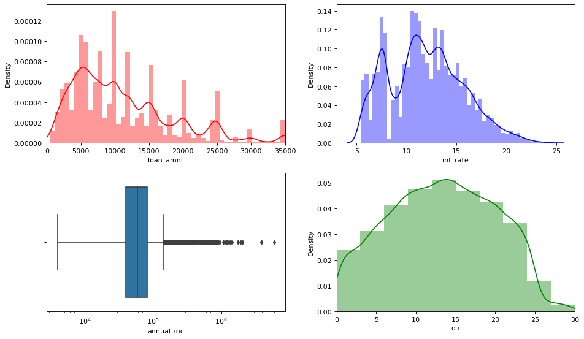

```python
#charged_off = loan.loc[loan['loan_status']=='Charged Off']

plt.figure(figsize=(12, 10), dpi=80, facecolor='w', edgecolor='k')

# subplot 1: loan_amnt
plt.subplot(3, 2, 1)
sns.distplot(loan['loan_amnt'], color='red')
plt.xlim([0, 35000])

# subplot 2: int_rate
plt.subplot(3, 2, 2)
sns.distplot(loan['int_rate'], color='blue')


# subplot 3: annual_inc
plt.subplot(3, 2, 3)
plt.xscale('log')
sns.boxplot('annual_inc', data=loan)


# subplot 4: dti
plt.subplot(3, 2, 4)
sns.distplot(loan['dti'], color='green', bins=10)
plt.xlim([0, 30])

plt.tight_layout()
plt.show()
```

- We can see that most of the loans are in the range of 2000 to 16000.
- Most Loan interest rates are in between 5% to 10% and 10% to 15%, the trend decreases after 15.
- The frequency distribution of dti seems to be symmetric in nature centered around 15.
- There are quite a few top outlier values in annual income of borrowers.

### Some more Insights based on factors like loan terms, grades, employess lengths, home ownerships, loan verification status, loan purpose and derogatory public records`

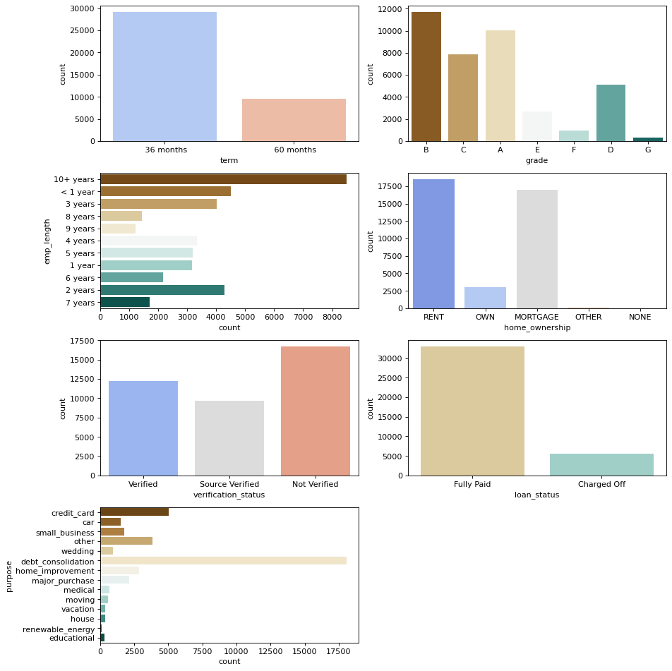

```python
plt.figure(figsize=(12, 12), dpi=80, facecolor='w', edgecolor='k')

# subplot 1: Terms
plt.subplot(4, 2, 1)
sns.countplot(x='term', palette='coolwarm', data=loan)

# subplot 2: Grade
plt.subplot(4, 2, 2)
sns.countplot(x='grade', palette='BrBG', data=loan)

# subplot 3: Emp_length
plt.subplot(4, 2, 3)
sns.countplot(y='emp_length', palette='BrBG', data=loan)

# subplot 4: home_ownership
plt.subplot(4, 2, 4)
sns.countplot(x='home_ownership', palette='coolwarm', data=loan)

# subplot 5: verification_status
plt.subplot(4, 2, 5)
sns.countplot(x='verification_status', palette='coolwarm', data=loan)

# subplot 6: loan_status
plt.subplot(4, 2, 6)
sns.countplot(x='loan_status', palette='BrBG', data=loan)

# subplot 7: purpose
plt.subplot(4, 2, 7)
sns.countplot(y='purpose', palette='BrBG', data=loan)

plt.tight_layout()
plt.show()
```

```python
print("%.2f" % (loan.loc[loan['loan_status'] == 'Charged Off'].loan_status.count() * 100/len(loan)))
```

```
14.59
```

Approximately **14.6%** of loans in the dataset are **defaulted.**

# Bivariate Analysis

### Loan Purpose

```python
loan_purpose = pd.DataFrame(loan.groupby('purpose')['charged_off','fully_paid'].sum().reset_index())
loan_purpose
```

|  | purpose | charged_off | fully_paid |
| --- | --- | --- | --- |
| 0 | car | 160 | 1339 |
| 1 | credit_card | 542 | 4485 |
| 2 | debt_consolidation | 2767 | 15288 |
| 3 | educational | 56 | 269 |
| 4 | home_improvement | 347 | 2528 |
| 5 | house | 59 | 308 |
| 6 | major_purchase | 222 | 1928 |
| 7 | medical | 106 | 575 |
| 8 | moving | 92 | 484 |
| 9 | other | 633 | 3232 |
| 10 | renewable_energy | 19 | 83 |
| 11 | small_business | 475 | 1279 |
| 12 | vacation | 53 | 322 |
| 13 | wedding | 96 | 830 |

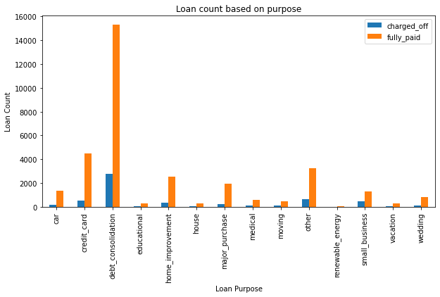

```python
#bar chart
loan_purpose.plot.bar(x='purpose', y=['charged_off','fully_paid'],figsize=[10,5])
plt.ylabel('Loan Count')
plt.xlabel('Loan Purpose')
plt.title("Loan count based on purpose")
```

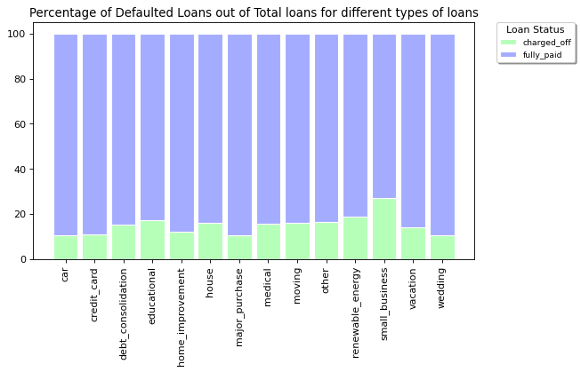

```python
# Calculate percentage
r = [0,1,2,3,4,5,6,7,8,9,10,11,12,13]
totals = [i+j for i,j in zip(loan_purpose['charged_off'], loan_purpose['fully_paid'])]
charged_off = [i / j * 100 for i,j in zip(loan_purpose['charged_off'], totals)]
fully_paid = [i / j * 100 for i,j in zip(loan_purpose['fully_paid'], totals)]
names = list(loan_purpose['purpose'])

# plot
plt.figure(figsize=(8, 15), dpi=80, facecolor='w', edgecolor='k')

# subplot 1: stacked bar
plt.subplot(3, 1, 1)
barWidth = 0.85
# Create charged_off Bars
plt.bar(r, charged_off, color='#b5ffb9', edgecolor='white', width=barWidth)
# Create fully paid Bars
plt.bar(r, fully_paid, bottom=[i for i in charged_off], color='#a3acff', edgecolor='white', width=barWidth)
# Custom x axis
plt.xticks(r, names, rotation='vertical')
plt.legend(['charged_off','fully_paid'],frameon=True, fontsize='small', shadow='True', title='Loan Status', bbox_to_anchor=(1.05, 1), loc=2, borderaxespad=0.)
plt.title("Percentage of Defaulted Loans out of Total loans for different types of loans")
```

- Small business have highest % of charged off loans.
- Debt_consolidation has highest no of charged off loans.

### Loan Term

```python
loan_term = pd.DataFrame(loan.groupby('term')['charged_off','fully_paid'].sum().reset_index())
loan_term
```

|  | term | charged_off | fully_paid |
| --- | --- | --- | --- |
| 0 | 36 months | 3227 | 25869 |
| 1 | 60 months | 2400 | 7081 |

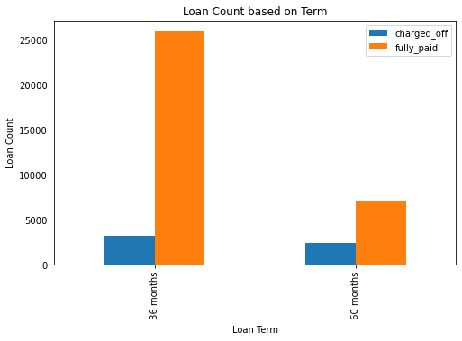

```python
#bar chart
loan_term.plot.bar(x='term', y=['charged_off','fully_paid'],figsize=[8,5])
plt.ylabel('Loan Count')
plt.xlabel('Loan Term')
plt.title("Loan Count based on Term")
```

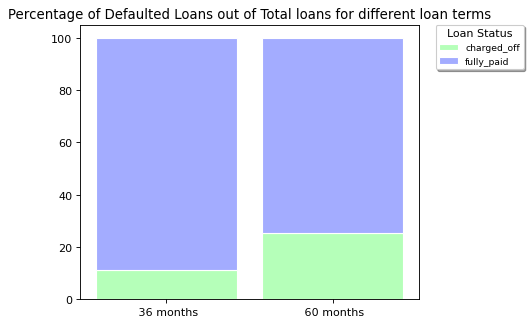

```python
#Calculate percentage
r = [0,1]
totals = [i+j for i,j in zip(loan_term['charged_off'], loan_term['fully_paid'])]
charged_off = [i / j * 100 for i,j in zip(loan_term['charged_off'], totals)]
fully_paid = [i / j * 100 for i,j in zip(loan_term['fully_paid'], totals)]
names = list(loan_term['term'])

# plot
plt.figure(figsize=(12, 10), dpi=80, facecolor='w', edgecolor='k')

#stacked bar
plt.subplot(2, 2, 1)
barWidth = 0.85
# Create charged_off Bars
plt.bar(r, charged_off, color='#b5ffb9', edgecolor='white', width=barWidth)
# Create fully paid Bars
plt.bar(r, fully_paid, bottom=[i for i in charged_off], color='#a3acff', edgecolor='white', width=barWidth)
# Custom x axis
plt.xticks(r, names)
plt.legend(['charged_off','fully_paid'],frameon=True, fontsize='small', shadow='True', title='Loan Status', bbox_to_anchor=(1.05, 1), loc=2, borderaxespad=0.)
plt.title("Percentage of Defaulted Loans out of Total loans for different loan terms")
```

- Loans whose term is over 60 months have deafault rate that is twice that of deafault rate of loans whose term is 36 months.
- We can also observe that more deafulters are observed in loans that spans over 36 months as compared to loans that spans over 60months

### Loan Issue Date

```python
loan_issue_yr = pd.DataFrame(loan.groupby('issue_d_year')['charged_off','fully_paid'].sum().reset_index())
loan_issue_yr
```

|  | issue_d_year | charged_off | fully_paid |
| --- | --- | --- | --- |
| 0 | 2007 | 45 | 206 |
| 1 | 2008 | 247 | 1315 |
| 2 | 2009 | 594 | 4122 |
| 3 | 2010 | 1485 | 10047 |
| 4 | 2011 | 3256 | 17260 |

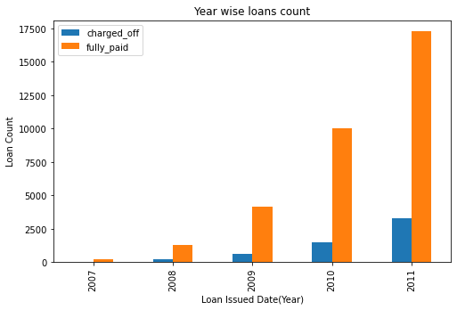

```python
#bar chart
loan_issue_yr.plot.bar(x='issue_d_year', y=['charged_off','fully_paid'],figsize=[8,5])
plt.ylabel('Loan Count')
plt.xlabel('Loan Issued Date(Year)')
plt.title("Year wise loans count")
```

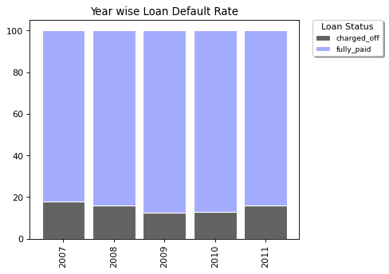

```python
#percentage
r = list(loan_issue_yr.index)                 #r = [0,1,2]
totals = [i+j for i,j in zip(loan_issue_yr['charged_off'], loan_issue_yr['fully_paid'])]
charged_off = [i / j * 100 for i,j in zip(loan_issue_yr['charged_off'], totals)]
fully_paid = [i / j * 100 for i,j in zip(loan_issue_yr['fully_paid'], totals)]
names = list(loan_issue_yr['issue_d_year'])

# plot
plt.figure(figsize=(12, 10), dpi=80, facecolor='w', edgecolor='k')

#stacked bar
plt.subplot(2, 2, 1)
barWidth = 0.85
# Create charged_off Bars
plt.bar(r, charged_off, color='#636363', edgecolor='white', width=barWidth)
# Create fully paid Bars
plt.bar(r, fully_paid, bottom=[i for i in charged_off], color='#a3acff', edgecolor='white', width=barWidth)
# Custom x axis
plt.xticks(r, names, rotation='vertical')
plt.legend(['charged_off','fully_paid'],frameon=True, fontsize='small', shadow='True', title='Loan Status', bbox_to_anchor=(1.05, 1), loc=2, borderaxespad=0.)
plt.title("Year wise Loan Default Rate")
```

- Its evident that no of Defaulters are increasing every year
- Its also interesting to note that though defaulters are increasing the default rate was maximum on 2007 followed by 2011

### Interest Rate

```python
loan_ir = pd.DataFrame(loan.groupby('interest_rate_bins')['charged_off','fully_paid'].sum().reset_index())
loan_ir
```

|  | interest_rate_bins | charged_off | fully_paid |
| --- | --- | --- | --- |
| 0 | Low | 830 | 11486 |
| 1 | Medium | 2707 | 15558 |
| 2 | High | 2090 | 5906 |

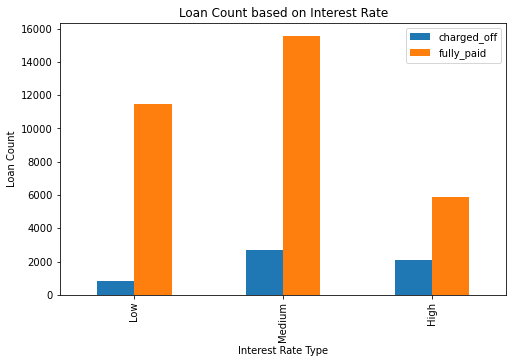

```python
#bar chart
loan_ir.plot.bar(x='interest_rate_bins', y=['charged_off','fully_paid'],figsize=[8,5])
plt.ylabel('Loan Count')
plt.xlabel('Interest Rate Type')
plt.title("Loan Count based on Interest Rate")
```

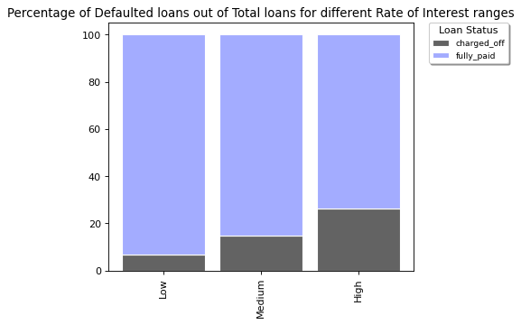

```python
#percentage
r = [0,1,2]
totals = [i+j for i,j in zip(loan_ir['charged_off'], loan_ir['fully_paid'])]
charged_off = [i / j * 100 for i,j in zip(loan_ir['charged_off'], totals)]
fully_paid = [i / j * 100 for i,j in zip(loan_ir['fully_paid'], totals)]
names = list(loan_ir['interest_rate_bins'])

# plot

plt.figure(figsize=(12, 10), dpi=80, facecolor='w', edgecolor='k')

#stacked bar
plt.subplot(2, 2, 1)
barWidth = 0.85
# Create charged_off Bars
plt.bar(r, charged_off, color='#636363', edgecolor='white', width=barWidth)
# Create fully paid Bars
plt.bar(r, fully_paid, bottom=[i for i in charged_off], color='#a3acff', edgecolor='white', width=barWidth)
# Custom x axis
plt.xticks(r, names, rotation='vertical')
plt.legend(['charged_off','fully_paid'],frameon=True, fontsize='small', shadow='True', title='Loan Status', bbox_to_anchor=(1.05, 1), loc=2, borderaxespad=0.)
plt.title("Percentage of Defaulted loans out of Total loans for different Rate of Interest ranges")
```

- We can observe that the default rate increases as the rate of interest increases.
- The defaulters are more likely observed in loans where interest rate is between 10% and 15%

## Loan Grade

```python
loan_grade = pd.DataFrame(loan.groupby('grade')['charged_off','fully_paid'].sum().reset_index())
loan_grade
```

|  | grade | charged_off | fully_paid |
| --- | --- | --- | --- |
| 0 | A | 602 | 9443 |
| 1 | B | 1425 | 10250 |
| 2 | C | 1347 | 6487 |
| 3 | D | 1118 | 3967 |
| 4 | E | 715 | 1948 |
| 5 | F | 319 | 657 |
| 6 | G | 101 | 198 |

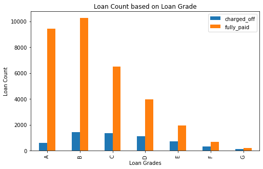

```python
#bar chart
loan_grade.plot.bar(x='grade', y=['charged_off','fully_paid'],figsize=[8,5])
plt.ylabel('Loan Count')
plt.xlabel('Loan Grades')
plt.title("Loan Count based on Loan Grade")
```

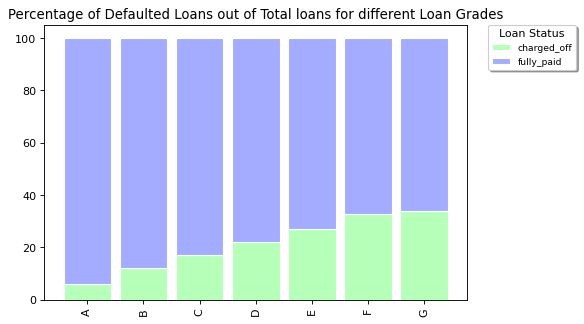

```python
#Calculate percentage
r = [0,1,2,3,4,5,6]
totals = [i+j for i,j in zip(loan_grade['charged_off'], loan_grade['fully_paid'])]
charged_off = [i / j * 100 for i,j in zip(loan_grade['charged_off'], totals)]
fully_paid = [i / j * 100 for i,j in zip(loan_grade['fully_paid'], totals)]
names = list(loan_grade['grade'])

# plot
plt.figure(figsize=(15, 10), dpi=80, facecolor='w', edgecolor='k')

#stacked bar
plt.subplot(2, 2, 1)
barWidth = 0.85
# Create charged_off Bars
plt.bar(r, charged_off, color='#b5ffb9', edgecolor='white', width=barWidth)
# Create fully paid Bars
plt.bar(r, fully_paid, bottom=[i for i in charged_off], color='#a3acff', edgecolor='white', width=barWidth)
# Custom x axis
plt.xticks(r, names, rotation='vertical')
plt.legend(['charged_off','fully_paid'],frameon=True, fontsize='small', shadow='True', title='Loan Status', bbox_to_anchor=(1.05, 1), loc=2, borderaxespad=0.)
plt.title("Percentage of Defaulted Loans out of Total loans for different Loan Grades")
```

- Default rate in loan increases from grade A to G.
- Loan applications with grades B, C and D have the highest no of Defaulters

### Sub Grade Analysis

```python
loan_subgrade = pd.DataFrame(loan.groupby(['sub_grade'])['charged_off','fully_paid'].sum())
loan_subgrade
```

| sub_grade | charged_off | fully_paid |
| --- | --- | --- |
| A1 | 30 | 1109 |
| A2 | 74 | 1434 |
| A3 | 103 | 1707 |
| A4 | 178 | 2695 |
| A5 | 217 | 2498 |
| B1 | 171 | 1626 |
| B2 | 228 | 1773 |
| B3 | 341 | 2484 |
| B4 | 329 | 2108 |
| B5 | 356 | 2259 |
| C1 | 336 | 1719 |
| C2 | 321 | 1610 |
| C3 | 270 | 1218 |
| C4 | 212 | 994 |
| C5 | 208 | 946 |
| D1 | 167 | 764 |
| D2 | 271 | 1015 |
| D3 | 256 | 860 |
| D4 | 215 | 703 |
| D5 | 209 | 625 |
| E1 | 198 | 524 |
| E2 | 163 | 451 |
| E3 | 119 | 397 |
| E4 | 126 | 298 |
| E5 | 109 | 278 |
| F1 | 91 | 214 |
| F2 | 70 | 163 |
| F3 | 51 | 123 |
| F4 | 53 | 98 |
| F5 | 54 | 59 |
| G1 | 31 | 63 |
| G2 | 28 | 49 |
| G3 | 19 | 26 |
| G4 | 13 | 41 |
| G5 | 10 | 19 |

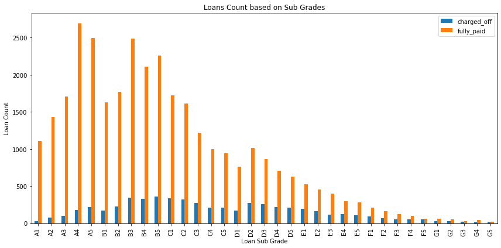

```python
#bar plot
loan_subgrade.plot.bar(figsize=(12,6))
plt.xlabel('Loan Sub Grade')
plt.ylabel('Loan Count')
plt.title("Loans Count based on Sub Grades")

plt.tight_layout()
plt.show()
```

### Employment Length(Borrower Experience)

```python
emp_exp = pd.DataFrame(loan.groupby('emp_length')['charged_off','fully_paid'].sum().reset_index())
emp_exp
```

|  | emp_length | charged_off | fully_paid |
| --- | --- | --- | --- |
| 0 | 1 year | 456 | 2713 |
| 1 | 10+ years | 1331 | 7157 |
| 2 | 2 years | 567 | 3724 |
| 3 | 3 years | 555 | 3457 |
| 4 | 4 years | 462 | 2880 |
| 5 | 5 years | 458 | 2736 |
| 6 | 6 years | 307 | 1861 |
| 7 | 7 years | 263 | 1448 |
| 8 | 8 years | 203 | 1232 |
| 9 | 9 years | 158 | 1068 |
| 10 | < 1 year | 639 | 3869 |

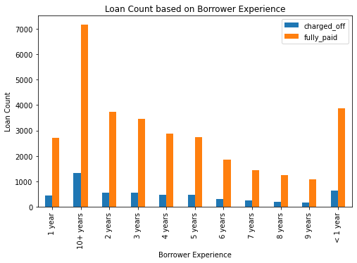

```python
#bar chart
emp_exp.plot.bar(x='emp_length', y=['charged_off','fully_paid'],figsize=[8,5])
plt.ylabel('Loan Count')
plt.xlabel('Borrower Experience')
plt.title("Loan Count based on Borrower Experience")
```

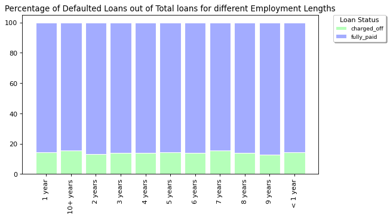

```python
#Percentage
r = [0,1,2,3,4,5,6,7,8,9,10]
totals = [i+j for i,j in zip(emp_exp['charged_off'], emp_exp['fully_paid'])]
charged_off = [i / j * 100 for i,j in zip(emp_exp['charged_off'], totals)]
fully_paid = [i / j * 100 for i,j in zip(emp_exp['fully_paid'], totals)]
names = list(emp_exp['emp_length'])

# plot
plt.figure(figsize=(8, 15), dpi=80, facecolor='w', edgecolor='k')

#stacked bar
plt.subplot(3, 1, 1)
barWidth = 0.85
# Create charged_off Bars
plt.bar(r, charged_off, color='#b5ffb9', edgecolor='white', width=barWidth)
# Create fully paid Bars
plt.bar(r, fully_paid, bottom=[i for i in charged_off], color='#a3acff', edgecolor='white', width=barWidth)
# Custom x axis
plt.xticks(r, names, rotation='vertical')
plt.legend(['charged_off','fully_paid'],frameon=True, fontsize='small', shadow='True', title='Loan Status', bbox_to_anchor=(1.05, 1), loc=2, borderaxespad=0.)
plt.title("Percentage of Defaulted Loans out of Total loans for different Employment Lengths")
```

- Here we can see that more defaulters can be observed in the bins where borrowers experience are 10+ years and 1 year or lesser
- As far as default rate is concerned no significant trend is seen as all of them are more or less closer to each other

### Analysis on Home Ownership

```python
loan_home_ownership = pd.DataFrame(loan.groupby('home_ownership')['charged_off','fully_paid'].sum().reset_index())
loan_home_ownership
```

|  | home_ownership | charged_off | fully_paid |
| --- | --- | --- | --- |
| 0 | MORTGAGE | 2327 | 14694 |
| 1 | NONE | 0 | 3 |
| 2 | OTHER | 18 | 80 |
| 3 | OWN | 443 | 2532 |
| 4 | RENT | 2839 | 15641 |

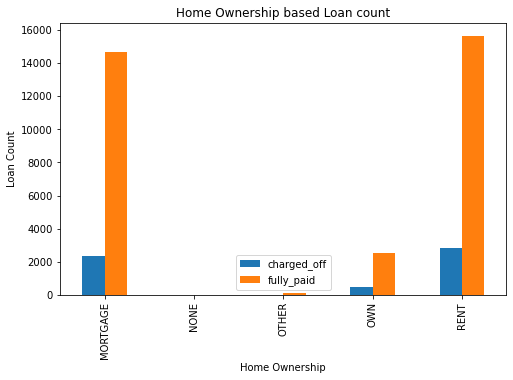

```python
#bar chart
loan_home_ownership.plot.bar(x='home_ownership', y=['charged_off','fully_paid'],figsize=[8,5])
plt.ylabel('Loan Count')
plt.xlabel('Home Ownership')
plt.title("Home Ownership based Loan count")
```

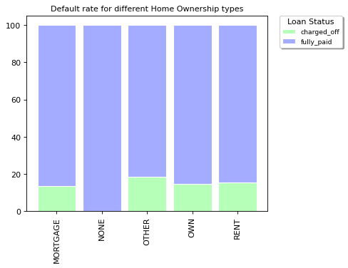

```python
# From raw value to percentage
r = [0,1,2,3,4]
totals = [i+j for i,j in zip(loan_home_ownership['charged_off'], loan_home_ownership['fully_paid'])]
charged_off = [i / j * 100 for i,j in zip(loan_home_ownership['charged_off'], totals)]
fully_paid = [i / j * 100 for i,j in zip(loan_home_ownership['fully_paid'], totals)]
names = list(loan_home_ownership['home_ownership'])

# plot

plt.figure(figsize=(12, 10), dpi=80, facecolor='w', edgecolor='k')

#stacked bar
plt.subplot(2, 2, 1)
barWidth = 0.85
# Create charged_off Bars
plt.bar(r, charged_off, color='#b5ffb9', edgecolor='white', width=barWidth)
# Create fully paid Bars
plt.bar(r, fully_paid, bottom=[i for i in charged_off], color='#a3acff', edgecolor='white', width=barWidth)
# Custom x axis
plt.xticks(r, names, rotation='vertical')
plt.legend(['charged_off','fully_paid'],frameon=True, fontsize='small', shadow='True', title='Loan Status', bbox_to_anchor=(1.05, 1), loc=2, borderaxespad=0.)
plt.title("Default rate for different Home Ownership types", fontsize='medium')
```

- Default rate in home ownership type 'Other' is slightly high over others.
- It appears that most defaulters are the borrowers with ownership types house-mortgage and house-rent.

### Analysis on Verification_status

```python
loan_verification_status = pd.DataFrame(loan.groupby('verification_status')['charged_off','fully_paid'].sum().reset_index())
loan_verification_status
```

|  | verification_status | charged_off | fully_paid |
| --- | --- | --- | --- |
| 0 | Not Verified | 2142 | 14552 |
| 1 | Source Verified | 1434 | 8243 |
| 2 | Verified | 2051 | 10155 |

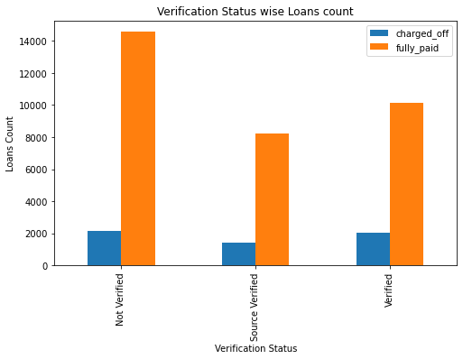

```python
#bar chart
loan_verification_status.plot.bar(x='verification_status', y=['charged_off','fully_paid'],figsize=[8,5])
plt.ylabel('Loans Count')
plt.xlabel('Verification Status')
plt.title("Verification Status wise Loans count")
```

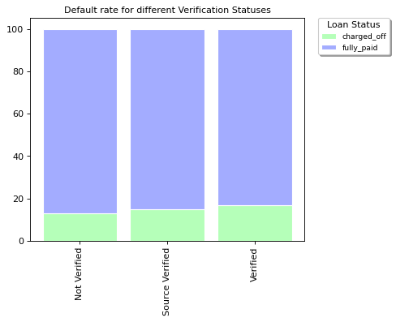

```python
#Calculate percentage
r = [0,1,2]
totals = [i+j for i,j in zip(loan_verification_status['charged_off'], loan_verification_status['fully_paid'])]
charged_off = [i / j * 100 for i,j in zip(loan_verification_status['charged_off'], totals)]
fully_paid = [i / j * 100 for i,j in zip(loan_verification_status['fully_paid'], totals)]
names = list(loan_verification_status['verification_status'])

# plot

plt.figure(figsize=(12, 10), dpi=80, facecolor='w', edgecolor='k')

#stacked bar
plt.subplot(2, 2, 1)
barWidth = 0.85
# Create charged_off Bars
plt.bar(r, charged_off, color='#b5ffb9', edgecolor='white', width=barWidth)
# Create fully paid Bars
plt.bar(r, fully_paid, bottom=[i for i in charged_off], color='#a3acff', edgecolor='white', width=barWidth)
# Custom x axis
plt.xticks(r, names, rotation='vertical')
plt.legend(['charged_off','fully_paid'],frameon=True, fontsize='small', shadow='True', title='Loan Status', bbox_to_anchor=(1.05, 1), loc=2, borderaxespad=0.)
plt.title("Default rate for different Verification Statuses", fontsize='medium')
```

- Default Rate is slightly more for ‘Verified’ loans followed by ‘Source verified’ ones and ‘Not verified’ ones

### Analysis considering loans from various states

```python
loan_addr_state = pd.DataFrame(loan.groupby('addr_state')['charged_off','fully_paid'].sum().reset_index())
loan_addr_state
```

|  | addr_state | charged_off | fully_paid |
| --- | --- | --- | --- |
| 0 | AK | 15 | 63 |
| 1 | AL | 54 | 381 |
| 2 | AR | 27 | 208 |
| 3 | AZ | 123 | 726 |
| 4 | CA | 1125 | 5824 |
| 5 | CO | 98 | 668 |
| 6 | CT | 94 | 632 |
| 7 | DC | 15 | 196 |
| 8 | DE | 12 | 101 |
| 9 | FL | 504 | 2277 |
| 10 | GA | 215 | 1144 |
| 11 | HI | 28 | 138 |
| 12 | IA | 0 | 5 |
| 13 | ID | 1 | 5 |
| 14 | IL | 197 | 1281 |
| 15 | IN | 0 | 9 |
| 16 | KS | 31 | 224 |
| 17 | KY | 45 | 266 |
| 18 | LA | 53 | 374 |
| 19 | MA | 159 | 1138 |
| 20 | MD | 162 | 861 |
| 21 | ME | 0 | 3 |
| 22 | MI | 103 | 601 |
| 23 | MN | 81 | 524 |
| 24 | MO | 114 | 556 |
| 25 | MS | 2 | 17 |
| 26 | MT | 11 | 72 |
| 27 | NC | 114 | 636 |
| 28 | NE | 3 | 2 |
| 29 | NH | 25 | 141 |
| 30 | NJ | 278 | 1512 |
| 31 | NM | 30 | 153 |
| 32 | NV | 108 | 371 |
| 33 | NY | 495 | 3203 |
| 34 | OH | 155 | 1023 |
| 35 | OK | 40 | 247 |
| 36 | OR | 71 | 364 |
| 37 | PA | 180 | 1288 |
| 38 | RI | 25 | 169 |
| 39 | SC | 66 | 393 |
| 40 | SD | 12 | 50 |
| 41 | TN | 2 | 15 |
| 42 | TX | 316 | 2343 |
| 43 | UT | 40 | 212 |
| 44 | VA | 177 | 1192 |
| 45 | VT | 6 | 47 |
| 46 | WA | 127 | 691 |
| 47 | WI | 63 | 377 |
| 48 | WV | 21 | 151 |
| 49 | WY | 4 | 76 |

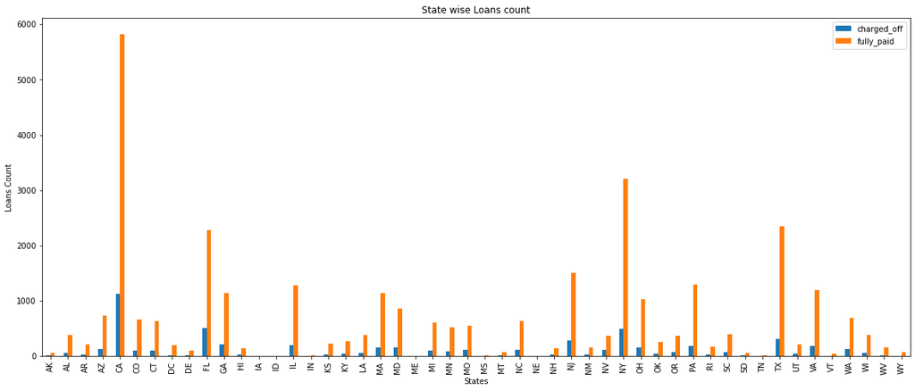

```python
#bar chart
loan_addr_state.plot.bar(x='addr_state', y=['charged_off','fully_paid'],figsize=[20,8])
plt.ylabel('Loans Count')
plt.xlabel('States')
plt.title("State wise Loans count")
```

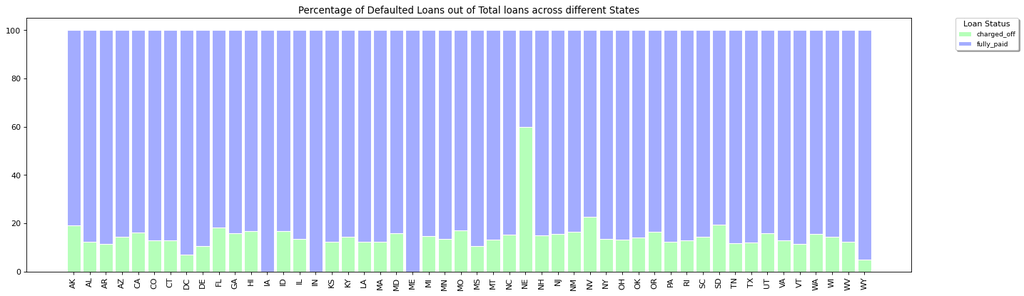

```python
# Calculate percentage
r = list(loan_addr_state.index)
totals = [i+j for i,j in zip(loan_addr_state['charged_off'], loan_addr_state['fully_paid'])]
charged_off = [i / j * 100 for i,j in zip(loan_addr_state['charged_off'], totals)]
fully_paid = [i / j * 100 for i,j in zip(loan_addr_state['fully_paid'], totals)]
names = list(loan_addr_state['addr_state'])

# plot
plt.figure(figsize=(20, 20), dpi=80, facecolor='w', edgecolor='k')

#stacked bar
plt.subplot(3, 1, 1)
barWidth = 0.85
# Create charged_off Bars
plt.bar(r, charged_off, color='#b5ffb9', edgecolor='white', width=barWidth)
# Create fully paid Bars
plt.bar(r, fully_paid, bottom=[i for i in charged_off], color='#a3acff', edgecolor='white', width=barWidth)
# Custom x axis
plt.xticks(r, names, rotation='vertical')
plt.legend(['charged_off','fully_paid'],frameon=True, fontsize='small', shadow='True', title='Loan Status', bbox_to_anchor=(1.05, 1), loc=2, borderaxespad=0.)
plt.title("Percentage of Defaulted Loans out of Total loans across different States")
```

### Analysis of Loans based on DTI

```python
loan_dti_bins = pd.DataFrame(loan.groupby('dti_bins')['charged_off','fully_paid'].sum().reset_index())
loan_dti_bins
```

|  | dti_bins | charged_off | fully_paid |
| --- | --- | --- | --- |
| 0 | Less Than 5 | 626 | 4436 |
| 1 | Btwn 5 & 10 | 1005 | 6868 |
| 2 | Btwn 10 & 15 | 1402 | 8228 |
| 3 | Btwn 15 & 20 | 1389 | 7422 |
| 4 | Btwn 20 & 25 | 1118 | 5460 |
| 5 | Btwn 25 & 30 | 87 | 536 |

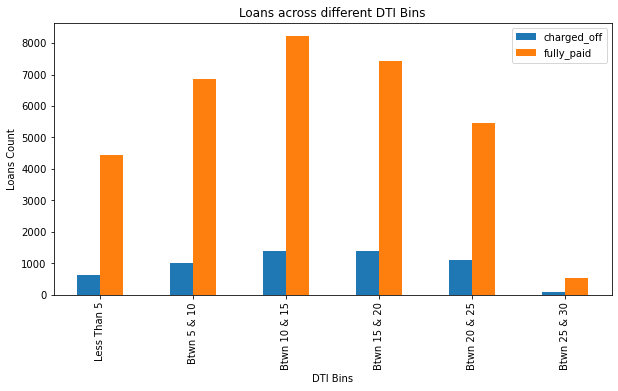

```python
#bar chart
loan_dti_bins.plot.bar(x='dti_bins', y=['charged_off','fully_paid'],figsize=[10,5])
plt.ylabel('Loans Count')
plt.xlabel('DTI Bins')
plt.title("Loans across different DTI Bins")
```

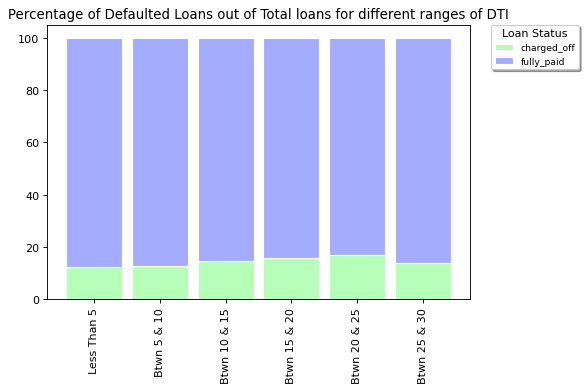

```python
# Compute percentage
r = list(loan_dti_bins.index)
totals = [i+j for i,j in zip(loan_dti_bins['charged_off'], loan_dti_bins['fully_paid'])]
charged_off = [i / j * 100 for i,j in zip(loan_dti_bins['charged_off'], totals)]
fully_paid = [i / j * 100 for i,j in zip(loan_dti_bins['fully_paid'], totals)]
names = list(loan_dti_bins['dti_bins'])

# plot
plt.figure(figsize=(15, 10), dpi=80, facecolor='w', edgecolor='k')

#stacked bar
plt.subplot(2, 2, 1)
barWidth = 0.85
# Create charged_off Bars
plt.bar(r, charged_off, color='#b5ffb9', edgecolor='white', width=barWidth)
# Create fully paid Bars
plt.bar(r, fully_paid, bottom=[i for i in charged_off], color='#a3acff', edgecolor='white', width=barWidth)
# Custom x axis
plt.xticks(r, names, rotation='vertical')
plt.legend(['charged_off','fully_paid'],frameon=True, fontsize='small', shadow='True', title='Loan Status', bbox_to_anchor=(1.05, 1), loc=2, borderaxespad=0.)
plt.title("Percentage of Defaulted Loans out of Total loans for different ranges of DTI")
```

### Analysis of Loans based on Public records

```python
loan_pub_rec = pd.DataFrame(loan.groupby('pub_rec')['charged_off','fully_paid'].sum().reset_index())
loan_pub_rec
```

|  | pub_rec | charged_off | fully_paid |
| --- | --- | --- | --- |
| 0 | 0 | 5160 | 31347 |
| 1 | 1 | 457 | 1556 |
| 2 | 2 | 10 | 38 |
| 3 | 3 | 0 | 7 |
| 4 | 4 | 0 | 2 |

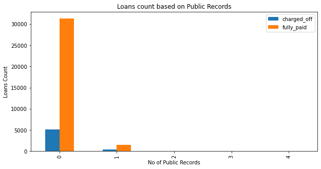

```python
#bar chart
loan_pub_rec.plot.bar(x='pub_rec', y=['charged_off','fully_paid'],figsize=[10,5])
plt.ylabel('Loans Count')
plt.xlabel('No of Public Records')
plt.title("Loans count based on Public Records")
```

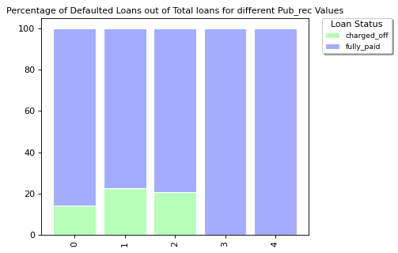

```python
# Compute percentage
r = list(loan_pub_rec.index)
totals = [i+j for i,j in zip(loan_pub_rec['charged_off'], loan_pub_rec['fully_paid'])]
charged_off = [i / j * 100 for i,j in zip(loan_pub_rec['charged_off'], totals)]
fully_paid = [i / j * 100 for i,j in zip(loan_pub_rec['fully_paid'], totals)]
names = list(loan_pub_rec['pub_rec'])

# plot
plt.figure(figsize=(12, 10), dpi=80, facecolor='w', edgecolor='k')

#stacked bar
plt.subplot(2, 2, 1)
barWidth = 0.85
# Create charged_off Bars
plt.bar(r, charged_off, color='#b5ffb9', edgecolor='white', width=barWidth)
# Create fully paid Bars
plt.bar(r, fully_paid, bottom=[i for i in charged_off], color='#a3acff', edgecolor='white', width=barWidth)
# Custom x axis
plt.xticks(r, names, rotation='vertical')
plt.legend(['charged_off','fully_paid'],frameon=True, fontsize='small', shadow='True', title='Loan Status', bbox_to_anchor=(1.05, 1), loc=2, borderaxespad=0.)
plt.title("Percentage of Defaulted Loans out of Total loans for different Pub_rec Values", fontsize='medium')
```

- Default Rate is highest for pub_rec value 1 and 2 compared to 0.

### Analysis of Loans based on Annual Income

```python
#Creating bins for Annual Income
cut_points = [0,20000,40000,60000,80000,100000,120000,140000,160000]
label_names = ["Less Than 20000","Btwn 20000 & 40000","Btwn 40000 & 60000","Btwn 60000 & 80000","Btwn 80000 & 100000","Btwn 100000 & 120000","Btwn 120000 & 140000","Above 140000"]


column_index = loan.columns.get_loc('annual_inc') + 1
loan.insert(loc=column_index,column='annual_inc_range',value=pd.cut(loan['annual_inc'],cut_points,labels=label_names, include_lowest=True))
loan
```

|  | id | member_id | loan_amnt | funded_amnt | funded_amnt_inv | term | int_rate | interest_rate_bins | installment | grade | sub_grade | emp_title | emp_length | home_ownership | annual_inc | annual_inc_range | verification_status | issue_d | loan_status | purpose | addr_state | dti | dti_bins | delinq_2yrs | earliest_cr_line | inq_last_6mths | open_acc | pub_rec | revol_bal | … |
| --- | --- | --- | --- | --- | --- | --- | --- | --- | --- | --- | --- | --- | --- | --- | --- | --- | --- | --- | --- | --- | --- | --- | --- | --- | --- | --- | --- | --- | --- | --- |
| 0 | 1077501 | 1296599 | 5000 | 5000 | 4975.0 | 36 months | 10.65 | Medium | 162.87 | B | B2 | NaN | 10+ years | RENT | 24000.0 | Btwn 20000 & 40000 | Verified | 2011-12-01 | Fully Paid | credit_card | AZ | 27.65 | Btwn 25 & 30 | 0 | Jan-85 | 1 | 3 | 0 | 13648 | … |
| 1 | 1077430 | 1314167 | 2500 | 2500 | 2500.0 | 60 months | 15.27 | High | 59.83 | C | C4 | Ryder | < 1 year | RENT | 30000.0 | Btwn 20000 & 40000 | Source Verified | 2011-12-01 | Charged Off | car | GA | 1.00 | Less Than 5 | 0 | Apr-99 | 5 | 3 | 0 | 1687 | … |
| 2 | 1077175 | 1313524 | 2400 | 2400 | 2400.0 | 36 months | 15.96 | High | 84.33 | C | C5 | NaN | 10+ years | RENT | 12252.0 | Less Than 20000 | Not Verified | 2011-12-01 | Fully Paid | small_business | IL | 8.72 | Btwn 5 & 10 | 0 | Nov-01 | 2 | 2 | 0 | 2956 | … |
| 3 | 1076863 | 1277178 | 10000 | 10000 | 10000.0 | 36 months | 13.49 | Medium | 339.31 | C | C1 | AIR RESOURCES BOARD | 10+ years | RENT | 49200.0 | Btwn 40000 & 60000 | Source Verified | 2011-12-01 | Fully Paid | other | CA | 20.00 | Btwn 15 & 20 | 0 | Feb-96 | 1 | 10 | 0 | 5598 | … |
| 5 | 1075269 | 1311441 | 5000 | 5000 | 5000.0 | 36 months | 7.90 | Low | 156.46 | A | A4 | Veolia Transportaton | 3 years | RENT | 36000.0 | Btwn 20000 & 40000 | Source Verified | 2011-12-01 | Fully Paid | wedding | AZ | 11.20 | Btwn 10 & 15 | 0 | Nov-04 | 3 | 9 | 0 | 7963 | … |
| ... | ... | ... | ... | ... | ... | ... | ... | ... | ... | ... | ... | ... | ... | ... | ... | ... | ... | ... | ... | ... | ... | ... | ... | ... | ... | ... | ... | ... | ... | … |
| 39712 | 92187 | 92174 | 2500 | 2500 | 1075.0 | 36 months | 8.07 | Low | 78.42 | A | A4 | FiSite Research | 4 years | MORTGAGE | 110000.0 | Btwn 100000 & 120000 | Not Verified | 2007-07-01 | Fully Paid | home_improvement | CO | 11.33 | Btwn 10 & 15 | 0 | Nov-90 | 0 | 13 | 0 | 7274 | … |
| 39713 | 90665 | 90607 | 8500 | 8500 | 875.0 | 36 months | 10.28 | Medium | 275.38 | C | C1 | Squarewave Solutions, Ltd. | 3 years | RENT | 18000.0 | Less Than 20000 | Not Verified | 2007-07-01 | Fully Paid | credit_card | NC | 6.40 | Btwn 5 & 10 | 1 | Dec-86 | 1 | 6 | 0 | 8847 | … |
| 39714 | 90395 | 90390 | 5000 | 5000 | 1325.0 | 36 months | 8.07 | Low | 156.84 | A | A4 | NaN | < 1 year | MORTGAGE | 100000.0 | Btwn 80000 & 100000 | Not Verified | 2007-07-01 | Fully Paid | debt_consolidation | MA | 2.30 | Less Than 5 | 0 | Oct-98 | 0 | 11 | 0 | 9698 | … |
| 39715 | 90376 | 89243 | 5000 | 5000 | 650.0 | 36 months | 7.43 | Low | 155.38 | A | A2 | NaN | < 1 year | MORTGAGE | 200000.0 | NaN | Not Verified | 2007-07-01 | Fully Paid | other | MD | 3.72 | Less Than 5 | 0 | Nov-88 | 0 | 17 | 0 | 85607 | … |
| 39716 | 87023 | 86999 | 7500 | 7500 | 800.0 | 36 months | 13.75 | Medium | 255.43 | E | E2 | Evergreen Center | < 1 year | OWN | 22000.0 | Btwn 20000 & 40000 | Not Verified | 2007-06-01 | Fully Paid | debt_consolidation | MA | 14.29 | Btwn 10 & 15 | 1 | Oct-03 | 0 | 7 | 0 | 4175 | … |

38577 rows × 46 columns

```python
loan_inc = pd.DataFrame(loan.groupby('annual_inc_range')['charged_off','fully_paid'].sum().reset_index())
loan_inc
```

|  | annual_inc_range | charged_off | fully_paid |
| --- | --- | --- | --- |
| 0 | Less Than 20000 | 237 | 943 |
| 1 | Btwn 20000 & 40000 | 1514 | 7004 |
| 2 | Btwn 40000 & 60000 | 1729 | 9534 |
| 3 | Btwn 60000 & 80000 | 1024 | 6597 |
| 4 | Btwn 80000 & 100000 | 531 | 3983 |
| 5 | Btwn 100000 & 120000 | 244 | 2084 |
| 6 | Btwn 120000 & 140000 | 137 | 1081 |
| 7 | Above 140000 | 84 | 626 |

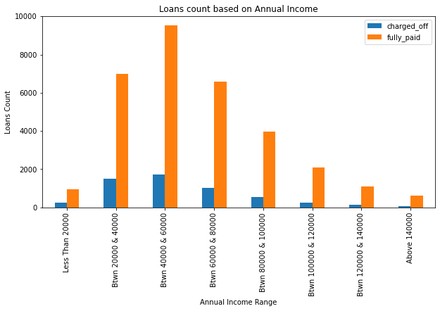

```python
#bar chart
loan_inc.plot.bar(x='annual_inc_range', y=['charged_off','fully_paid'],figsize=[10,5])
plt.ylabel('Loans Count')
plt.xlabel('Annual Income Range')
plt.title("Loans count based on Annual Income")
```

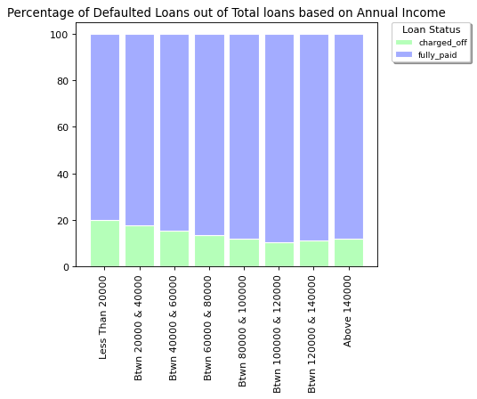

```python
# Compute Default Rate
r = list(loan_inc.index)
totals = [i+j for i,j in zip(loan_inc['charged_off'], loan_inc['fully_paid'])]
charged_off = [i / j * 100 for i,j in zip(loan_inc['charged_off'], totals)]
fully_paid = [i / j * 100 for i,j in zip(loan_inc['fully_paid'], totals)]
names = list(loan_inc['annual_inc_range'])

# plot
plt.figure(figsize=(12, 10), dpi=80, facecolor='w', edgecolor='k')

#stacked bar
plt.subplot(2, 2, 1)
barWidth = 0.85
# Create charged_off Bars
plt.bar(r, charged_off, color='#b5ffb9', edgecolor='white', width=barWidth)
# Create fully paid Bars
plt.bar(r, fully_paid, bottom=[i for i in charged_off], color='#a3acff', edgecolor='white', width=barWidth)
# Custom x axis
plt.xticks(r, names, rotation='vertical')
plt.legend(['charged_off','fully_paid'],frameon=True, fontsize='small', shadow='True', title='Loan Status', bbox_to_anchor=(1.05, 1), loc=2, borderaxespad=0.)
plt.title("Percentage of Defaulted Loans out of Total loans based on Annual Income")
```

### Lets see how the loan amount is distributed across loan statuses

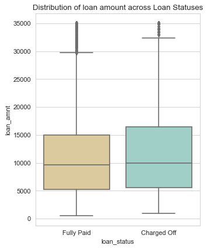

```python
# adjust figure size
plt.figure(figsize=(10, 6), dpi=80, facecolor='w', edgecolor='k', frameon='True')
sns.set_style("whitegrid")

#box_plot
plt.subplot(1, 2, 1)
sns.boxplot(x='loan_status', y='loan_amnt', palette='BrBG', data=loan)
plt.title("Distribution of loan amount across Loan Statuses")
```

### Distribution of Annual Income across Loan Statuses

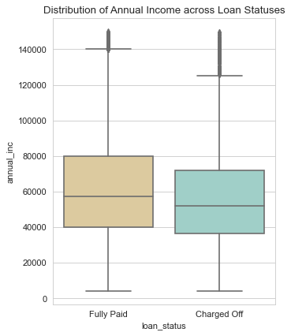

```python
#Distribution of Annual Income across Statuses
plt.figure(figsize=(10, 6), dpi=80, facecolor='w', edgecolor='k', frameon='True')
sns.set_style("whitegrid")

# subplot 1: box_plot
plt.subplot(1, 2, 1)
sns.boxplot(loan['loan_status'], loan['annual_inc'][loan['annual_inc'] < loan['annual_inc'].quantile(0.96)], palette='BrBG')
plt.title("Distribution of Annual Income across Loan Statuses")
```

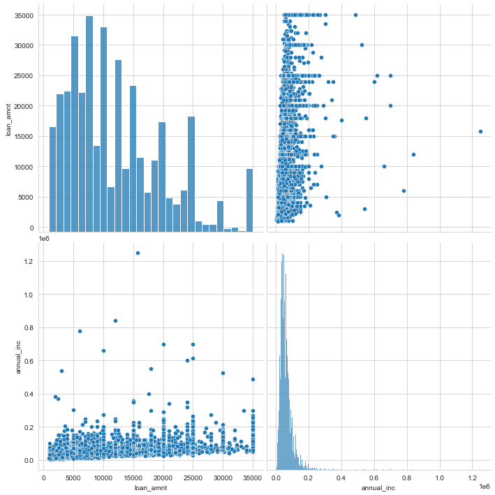

```python
#Variation of loan amount with annual income
plt.figure(figsize=(20, 20))
charged_off_loan = loan.loc[(loan['loan_status']=='Charged Off')]#[['loan_amnt','annual_inc']]
sns.pairplot(charged_off_loan, vars = ['loan_amnt','annual_inc'], size = 5)
plt.show()
```

### Correlation of some importamt variables of interest

```python
cor = charged_off_loan[['loan_amnt','funded_amnt', 'int_rate', 'installment','annual_inc','dti','open_acc','pub_rec']].corr()


round(cor, 2)
```

|  | loan_amnt | funded_amnt | int_rate | installment | annual_inc | dti | open_acc | pub_rec |
| --- | --- | --- | --- | --- | --- | --- | --- | --- |
| loan_amnt | 1.00 | 0.98 | 0.35 | 0.93 | 0.35 | 0.06 | 0.18 | -0.05 |
| funded_amnt | 0.98 | 1.00 | 0.35 | 0.95 | 0.35 | 0.06 | 0.18 | -0.05 |
| int_rate | 0.35 | 0.35 | 1.00 | 0.33 | 0.13 | 0.04 | 0.04 | 0.08 |
| installment | 0.93 | 0.95 | 0.33 | 1.00 | 0.36 | 0.04 | 0.18 | -0.04 |
| annual_inc | 0.35 | 0.35 | 0.13 | 0.36 | 1.00 | -0.09 | 0.21 | -0.01 |
| dti | 0.06 | 0.06 | 0.04 | 0.04 | -0.09 | 1.00 | 0.30 | 0.01 |
| open_acc | 0.18 | 0.18 | 0.04 | 0.18 | 0.21 | 0.30 | 1.00 | 0.05 |
| pub_rec | -0.05 | -0.05 | 0.08 | -0.04 | -0.01 | 0.01 | 0.05 | 1.00 |

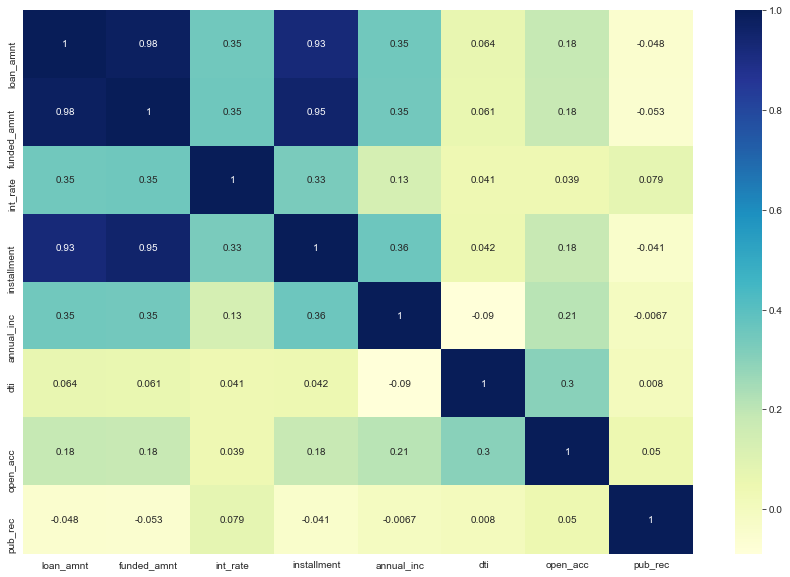

```python
plt.figure(figsize=(15,10))

# heatmap
sns.heatmap(cor, cmap="YlGnBu", annot=True)
plt.show()
```